# Project 1

Ola Rasmussen

### a)

$$\begin{aligned}
P(X_0 = k) &= \alpha_k, \ \ k=-1,0,1 \\
P(X_n = k | X_{n-1} = j) &= \beta_{jk}, \ \ j,k=-1,0,1 \\
Z_n &= \sum_{s=0}^n X_s
\end{aligned}$$

$\{X_n\}_{s=0}^n$ is a markov chain, and $F_n$ contains all the info of $\{X_n\}_{s=0}^n$ and $\{Z_n\}_{s=0}^n$.

Our goal in this problem is to find the restrictions of $\alpha_k$ and $\beta_{jk}$ so that $\{Z_n\}_{s=0}^n$ is a zero-mean martingale.

In other words, we need to show that $E[Z_n | F_{n-1}] = Z_{n-1}$.

$$\begin{aligned}
E[Z_n | F_{n-1}] &= E \Biggl[ \sum_{s=0}^n X_s \Bigg| F_{n-1}
\Biggr] \\
&= \sum_{s=0}^{n-1} X_s + E[X_n | F_{n-1}], \ \ using \ \ the \ \
markov \ \ property \\
&= Z_{n-1} + E[X_n | X_{n-1}] \\
&= Z_{n-1} + \sum_{k=-1}^1 k P(X_n = k | X_{n-1}) \\
&= Z_{n-1} + \Bigl(-1 \cdot P(X_n = -1 | X_{n-1}) + 0 \cdot P(X_n
= 0 | X_{n-1}) + 1 \cdot P(X_n = 1 | X_{n-1}) \Bigr) \\
&= Z_{n-1} + \Bigl(- \bigl(P(X_n=-1|X_{n-1}=-1)P(X_{n-1}=-1) +
P(X_n=-1|X_{n-1}=0)P(X_{n-1}=0) \\
&\ \ \ \ \ \ \ \ \ \ \ \ \ \ \ \ \ \ \ \ \ \ \ \ \ \ \ \ \ \ \ \ \
\ \ \ \ \ \ \ \ \ \ \ \ \ + P(X_n=-1|X_{n-1}=1)P(X_{n-1}=1)\bigr) \\
&\ \ \ \ \ \ \ \ \ \ \ \ \ \ \ +
\bigl(P(X_n=1|X_{n-1}=-1)P(X_{n-1}=-1) + P(X_n=1|X_{n-1}=0)P(X_{n-1}=0)
\\
&\ \ \ \ \ \ \ \ \ \ \ \ \ \ \ \ \ \ \ \ \ \ \ \ \ \ \ \ \ \ \ \ \
\ \ \ \ \ \ \ \ \ \ \ \ \ + P(X_n=1|X_{n-1}=1)P(X_{n-1}=1) \bigr) \Bigl)
\\
&= Z_{n-1} + \Bigl(-\bigl(\beta_{-1,-1}\alpha_{-1} +
\beta_{0,-1}\alpha_{0} + \beta_{1,-1}\alpha_{1} \bigr) +
\bigl(\beta_{-1,1}\alpha_{-1} + \beta_{0,1}\alpha_{0} +
\beta_{1,1}\alpha_{1} \bigr) \Bigl) \\
&= Z_{n-1} + \alpha_{-1}(\beta_{-1,1} - \beta_{-1,-1}) +
\alpha_{0}(\beta_{0,1} - \beta_{0,-1}) + \alpha_{1}(\beta_{1,1} -
\beta_{1,-1})
\end{aligned}$$

So we need $\alpha_{-1}(\beta_{-1,1} - \beta_{-1,-1}) + \alpha_{0}(\beta_{0,1} - \beta_{0,-1}) + \alpha_{1}(\beta_{1,1} - \beta_{1,-1}) = 0$, i.e. we need $\beta_{j,1} = \beta_{j,-1}$ and $\beta_{j,0} = 1 - 2\beta_{j,1} = 1 - 2\beta_{j,-1}$ where $j=-1,0,1$, and we need that $\sum_{j=-1}^1\beta_{jk} = 1$. We also need $\sum_{k=-1}^1\alpha_k = 1$.

we also get

$$\begin{aligned}
E[Z_n | F_{n-1}] &= \sum_{s=0}^{n-1}X_s + 0 + (0.01 - 0.01) + 0 \\
&= \sum_{s=0}^{n-1}X_s \\
&= Z_{n-1}
\end{aligned}$$

### b)

The formula for the predictable variation process is $\langle Z \rangle_n = \sum_{i=1}^n E[(Z_i - Z_{i-1})^2 | F_{n-1}]$, and the formula for the optional variation process is $\texttt{[} Z \texttt{]}_n = \sum_{i=1}^n (Z_i - Z_{i-1})^2$. Using these we find;

$$\begin{aligned}
\langle Z \rangle_n &= \sum_{i=1}^n E[(Z_i - Z_{i-1})^2 | F_{n-1}]
\\
&= \sum_{i=1}^n E[X_i^2 | F_{n-1}] \\
&= \sum_{i=1}^n E[X_i^2 | X_{n-1}], \ \ using \ \ the \ \ markov \
\ property \\
&= \sum_{i=1}^n \sum_{k=0}^1 kP(X_i^2 = k | X_{i-1}), \ \ using \
\ the \ \ markov \ \ property \\
&= \sum_{i=1}^n P(X_i^2 = 1 | X_{i-1}) \\
&= \sum_{i=1}^n \Bigl( P(X_i = -1 | X_{i-1}) + P(X_i = 1 |
X_{i-1}) \Bigr) \\
&= \sum_{i=1}^n (\beta_{i,-1} + \beta_{i,1}) \\
\\
\texttt{[} Z \texttt{]}_n &= \sum_{i=1}^n (Z_i - Z_{i-1})^2 \\
&= \sum_{i=1}^n X_i^2
\end{aligned}$$

### c)

```r
simFun <- function(N, alpha, beta) {
    x <- rep(0, N + 1)

    # Initial state
    u <- runif(1)
    if (u <= alpha[1]) {
        x[1] <- 0
    } else if (u <= alpha[2] + alpha[1]) {
        x[1] <- 1
    } else if (u >= 1 - alpha[3]) {
        x[1] <- 2
    }

    # Simulate next steps
    for (n in 1:N) {
        x[n + 1] <- sample.int(3, size = 1, replace = TRUE, prob = beta[x[n] +
            1, ]) - 1
    }
    x <- x - 1

    Z <- rep(0, N + 1)
    for (i in 1:(N + 1)) {
        Z[i] <- sum(x[1:i])
    }

    predZ <- rep(0, N + 1)
    test <- rep(0, N + 1)
    for (i in 2:(N + 1)) {
        test[i] <- beta[x[i - 1] + 2, 1] + beta[x[i - 1] + 2,
            3]
        predZ[i] <- sum(test[1:i])
    }

    optZ <- rep(0, N + 1)
    for (i in 1:(N + 1)) {
        optZ[i] <- sum(x[1:i]^2)
    }

    return(cbind(x, Z, predZ, optZ))
}
```

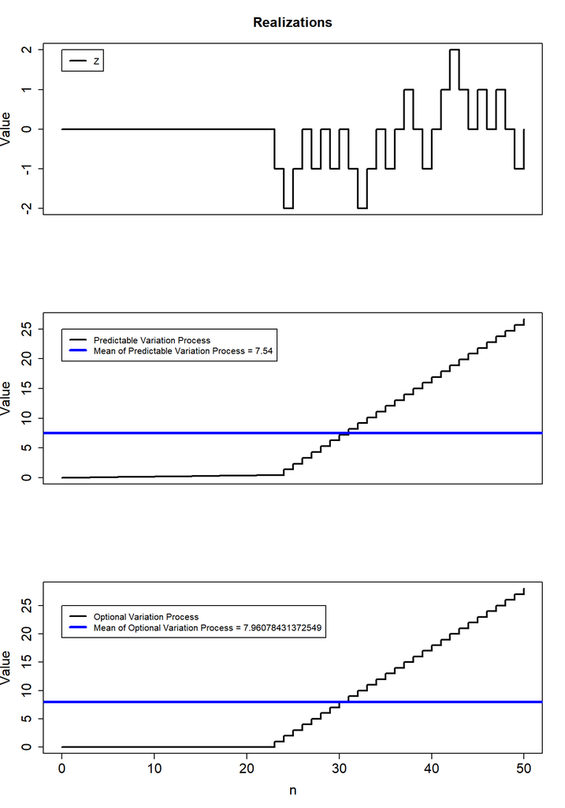

```r
set.seed(98)

N <- 50
alpha <- c(0, 1, 0)
beta <- matrix(c(0.48, 0.04, 0.48, 0.01, 0.98, 0.01, 0.49, 0.02,
    0.49), nrow = 3, byrow = T)

sim <- simFun(N, alpha, beta)

par(mfrow = c(3, 1))

plot(0:N, sim[, 2], type = "s", lwd = 2, cex.axis = 1.5, main = "Realizations",
    xlab = "", ylab = "Value", cex.lab = 1.5, cex.main = 1.5,
    xaxt = "n")
legend(0, 2, c("Z"), col = c("black"), lty = c(1), lwd = c(2))

plot(0:N, sim[, 3], type = "s", lwd = 2, cex.axis = 1.5, xlab = "",
    ylab = "Value", cex.lab = 1.5, cex.main = 1.5, xaxt = "n")
abline(h = mean(sim[, 3]), col = "blue", lwd = 3)
legend(0, 25, c("Predictable Variation Process", paste("Mean of Predictable Variation Process =",
    mean(sim[, 3]))), col = c("black", "blue"), lty = c(1, 1),
    lwd = c(2, 3))

plot(0:N, sim[, 4], type = "s", lwd = 2, cex.axis = 1.5, xlab = "n",
    ylab = "Value", cex.lab = 1.5, cex.main = 1.5)
abline(h = mean(sim[, 4]), col = "blue", lwd = 3)
legend(0, 25, c("Optional Variation Process", paste("Mean of Optional Variation Process =",
    mean(sim[, 4]))), col = c("black", "blue"), lty = c(1, 1),
    lwd = c(2, 3))
```

### d)

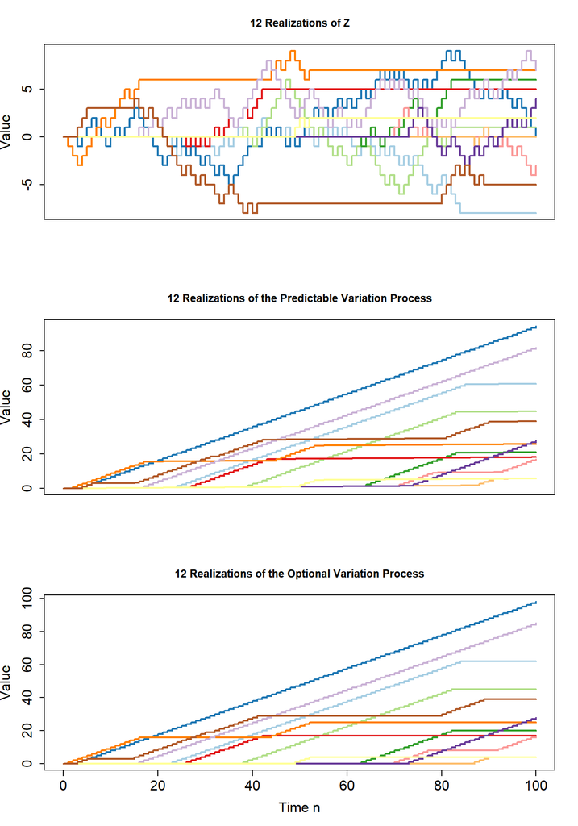

```r
N <- 100
M <- 12
Zmatr <- matrix(0, nrow = M, ncol = N + 1)
for (i in 1:M) {
    set.seed(97 + i)
    Zmatr[i, ] <- simFun(N, alpha, beta)[, 2]
}
predZmatr <- matrix(0, nrow = M, ncol = N + 1)
for (i in 1:M) {
    set.seed(97 + i)
    predZmatr[i, ] <- simFun(N, alpha, beta)[, 3]
}
optZmatr <- matrix(0, nrow = M, ncol = N + 1)
for (i in 1:M) {
    set.seed(97 + i)
    optZmatr[i, ] <- simFun(N, alpha, beta)[, 4]
}

cols <- brewer.pal(M, "Paired")
par(mfrow = c(3, 1))
plot(NULL, NULL, xlim = c(0, N), ylim = c(min(Zmatr), max(Zmatr)),
    main = paste(M, "Realizations of Z"), xlab = "", ylab = "Value",
    cex.axis = 1.5, cex.lab = 1.5, lwd = 1.5, xaxt = "n")
for (i in 1:M) {
    lines(0:N, Zmatr[i, ], col = cols[i], lwd = 2, type = "s")
}
plot(NULL, NULL, xlim = c(0, N), ylim = c(min(predZmatr), max(predZmatr)),
    main = paste(M, "Realizations of the Predictable Variation Process"),
    xlab = "", ylab = "Value", cex.axis = 1.5, cex.lab = 1.5,
    lwd = 1.5, xaxt = "n")
for (i in 1:M) {
    lines(0:N, predZmatr[i, ], col = cols[i], lwd = 2, type = "s")
}
# abline(h = mean(predZmatr), col = 'blue', lwd = 3)
plot(NULL, NULL, xlim = c(0, N), ylim = c(min(optZmatr), max(optZmatr)),
    main = paste(M, "Realizations of the Optional Variation Process"),
    xlab = "Time n", ylab = "Value", cex.axis = 1.5, cex.lab = 1.5,
    lwd = 1.5)
for (i in 1:M) {
    lines(0:N, optZmatr[i, ], col = cols[i], lwd = 2, type = "s")
}
```

```r
# abline(h = mean(optZmatr), col = 'blue', lwd = 3)
```

### e)

$$U_n = \sum_{s=0}^n \frac{X_s}{n-s+1}$$

Our goal now is to find the Doob decomposition of $\{ U_n \}_{n=0}^\infty$. i.e. $U_n = E[U_n | F_{n-1}] + \Delta M_n$, where $\{ M_n \}_{n=0}^\infty$ is a zero-mean martingale and $\Delta M_n = M_n - M_{n-1}$ for $n=0,1,...$.

$$\begin{aligned}
E[U_n | F_{n-1}] &= E \Biggl[ \sum_{s=0}^n \frac{X_s}{n-s+1} \Bigg|
F_{n-1} \Biggr] \\
&= \sum_{s=0}^{n-1} \frac{X_s}{n-s+1} + E \Biggl[
\frac{X_s}{n-n+1} \Bigg| F_{n-1} \Biggr] \\
&= U_{n-1} + E[X_n | X_{n-1}], \ \ using \ \ the \ \ markov \ \
property
\end{aligned}$$

We know that $E[X_n | X_{n-1}] = 0$ because $\sum_{s=0}^{n-1}X_s + E[X_n | X_{n-1}] = Z_{n-1} = \sum_{s=0}^{n-1}X_s \Rightarrow E[X_n | X_{n-1}] = 0$, which means that $E[U_n | F_{n-1}] = U_{n-1}$.

$$\begin{aligned}
U_n - E[U_n | F_{n-1}] &= U_n - U_{n-1} \\
&= X_n \\
&= \Delta M_n
\end{aligned}$$

So the Doob decomposition is:

$$U_n = U_{n-1} + X_n$$

# Problem 2:

### a)

We have:

$$\begin{aligned}
N(t) &= \sum_{i=1}^n N_i(t) \\
\\
Y(t) &= 1 + \sum_{i=2}^n Y_i(t) \\
\\
dN_i(t) &= N_i((t + dt)^-) - N_i(t^-) \\
\\
P(dN_i(t) = 1 | N_i(s), &Y_i(s); s \in [0,t]) = Y_i(t) \alpha(t) dt
\end{aligned}$$

The general formulation of the Doob-Meyer decomposition is $N(t) = N^*(t) + M(t)$. $N(t)$ is trivially a semi-martingale because is always increasing or staying the same, $E[N(t)|F_s] \ge N(s)$.

In particular, we want to use $dN^*(t) = E[dN(t) | F_{t^-}]$ to show that the compensator $N^*(t)$ of $N(t)$ is $N^*(t) = \int_0^t \alpha(t) Y(t) dt$.

$$\begin{aligned}
dN^*(t) &= E[dN(t) | F_{t^-}] \\
&= E[N((t + dt)^-) - N(t^-) | F_{t^-}] \\
&= E \Biggr[ \sum_{i=1}^n (N_i((t + dt)^-) - N_i(t^-)) | F_{t^-}
\Biggr] \\
&= \sum_{i=1}^n E[N_i((t + dt)^-) - N_i(t^-) | F_{t^-}] \\
&= \sum_{i=1}^n E[dN_i(t) | F_{t^-}] \\
&= \sum_{i=1}^n \Bigl(1 \cdot P(dN_i(t) = 1 | F_{t^-}) + 0 \cdot
P(dN_i(t) = 0 | F_{t^-}) \Bigr) \\
&= \sum_{i=1}^n P(dN_i(t) = 1 | F_{t^-}) \\
&= \sum_{i=1}^n Y_i(t) \alpha(t) dt \\
&= Y(t) \alpha(t) dt
\end{aligned}$$

Using that $\int_0^t dN^*(t) = N^*(t)$, we then get $N^*(t) = \int_0^t Y(t) \alpha(t) dt$.

So the Doob-Meyer decomposition is then $N(t) = \int_0^t Y(t) \alpha(t) dt + M(t)$.

### b)

The Doob-Meyer decomposition on increment form is:

$$\begin{aligned}
dN(t) &= dN^*(t) + dM(t) \\
&= Y(t) \alpha(t) dt + dM(t) \\
\\
Deviding \ \ by \ \ Y(t), \ \ we \ \ get &: \\
\\
\frac{dN(t)}{Y(t)} &= \alpha(t) dt + \frac{dM(t)}{Y(t)} \\
\\
Then \ \ we \ \ integrate \ \ both \ \ sides &: \\
\\
\int_0^t \frac{dN(s)}{Y(s)} &= A(t) + \int_0^t \frac{dM(s)}{Y(s)}
\end{aligned}$$

$\int_0^t \frac{dM(s)}{Y(s)}$ is a zero-mean martingale because $M(t)$ is a zero-mean martingale. This trivially means that $\hat A(t) = \int_0^t \frac{dN(s)}{Y(s)}$ is unbiased, because $E[\hat A(t)] = A(t)$.

### c)

We know that $\mathbb{I}(t) = \int_0^t H(s)dM(s)$ and that $\texttt{[} \int H dM \texttt{]} = \int H^2 d\texttt{[} M \texttt{]} = \int H^2 dN$. This means that:

$$\begin{aligned}
\texttt{[} \mathbb{I} \texttt{]} (t) &= \Biggr[ \int_0^t
\frac{dM(s)}{Y(s)} \Biggr] \Bigl(t\Bigr) \\
&= \int_0^t \frac{1}{Y^2(s)} d\texttt{[} M \texttt{]} (s) \\
&= \int_0^t \frac{1}{Y^2(s)}dN(s) \\
&= \sum_{j|T_j<t} \frac{1}{Y^2(T_j)}
\end{aligned}$$

### d)

```r
failureP <- function(alpha, v, n, tau) {
    en <- c()
    nul <- c()

    while (sum(en) + sum(nul) <= 60) {
        test <- sum(en) + sum(nul)
        en <- append(en, alphas(test))
        nul <- append(nul, rexp(1, v))
    }

    while (sum(en) + sum(nul) <= tau) {
        test <- sum(en) + sum(nul)
        en <- append(en, rexp(1, 1/10))
        nul <- append(nul, rexp(1, v))
    }

    if (length(en) >= length(nul)) {
        blabla <- length(en)
    } else {
        blabla <- length(nul)
    }

    TT <- c(0)
    TT[2] <- en[1]
    i <- 2
    while (i <= (blabla)) {
        TT[i + 1] <- sum(en[1:(i)]) + sum(nul[1:(i - 1)])
        i <- i + 1
    }

    S <- rep(0, blabla)
    S[1] <- TT[2] + nul[1]
    for (i in 2:(blabla)) {
        S[i] <- TT[i + 1] + nul[i]
    }

    return(cbind(TT, S, en, nul))
}
```

```r
alphas <- function(S) {
    u <- runif(1)
    integral <- (60^2 - S^2)/1200
    if (u <= (1 - exp(-integral))) {
        t <- sqrt(S^2 - (1200 * log(1 - u)))
    } else {
        t <- (60 - S) + rexp(1/10)
    }
    return(t)
}
v <- 0.2
n <- 25
tau <- 100
```

```r
set.seed(99)
fai <- failureP(alphas, v, n, tau)
TT <- fai[, 1]
S <- fai[, 2]
if (tail(TT, 1) < tau) {
    S <- append(S, tail(S, 1) + tail(fai[, 4], 1))
}
```

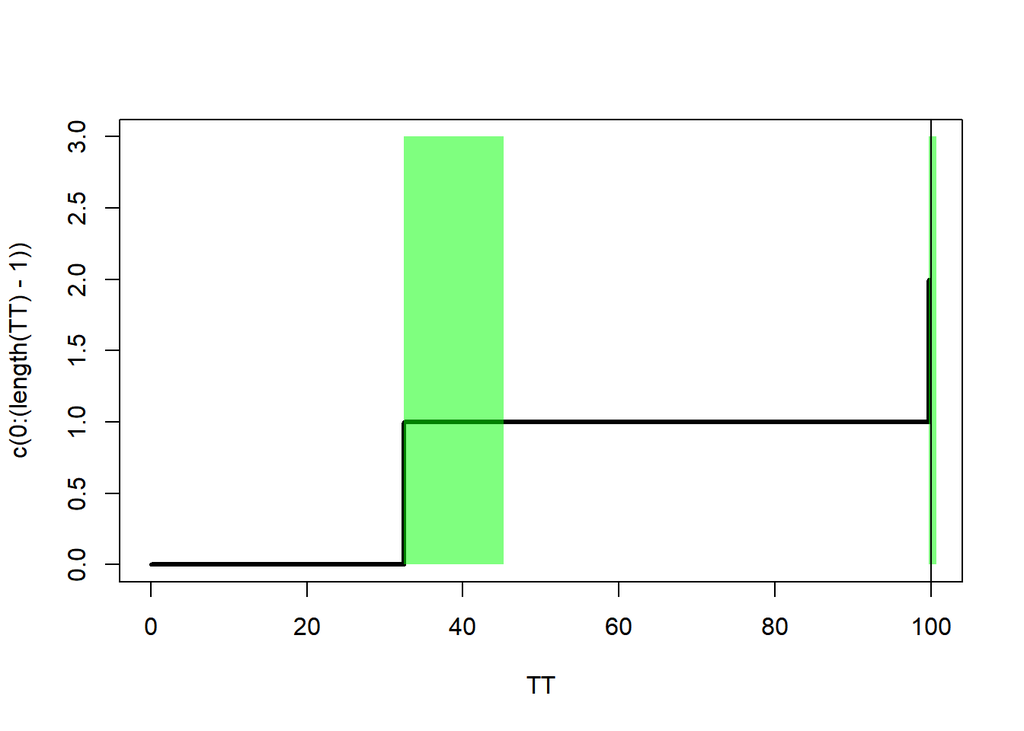

```r
plot(TT, c(0:(length(TT) - 1)), xlim = c(0, tau), ylim = c(0,
    length(TT)), type = "s", lwd = 3)
for (i in 2:length(TT)) {
    rect(TT[i], 0, S[i - 1], length(TT), col = alpha("green",
        0.5), border = NA)
}
abline(v = tau)
```

```r
TTMATR <- matrix(NA, nrow = 25, ncol = 25)
SMATR <- matrix(NA, nrow = 25, ncol = 25)
for (i in 1:2) {
    set.seed(97 + i)
    fai <- failureP(alphas, v, n, tau)
    TT <- fai[, 1]
    S <- fai[, 2]
    if (tail(TT, 1) < tau) {
        S <- append(S, tail(S, 1) + tail(fai[, 4], 1))
    }
    TTMATR[i, ] <- append(TT, rep(NA, ncol(TTMATR) - length(TT)))
    SMATR[i, ] <- append(S, rep(NA, ncol(SMATR) - length(S)))
}
```

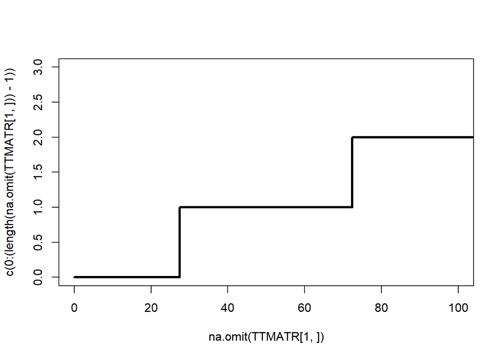

```r
plot(na.omit(TTMATR[1, ]), c(0:(length(na.omit(TTMATR[1, ])) -
    1)), xlim = c(0, tau), ylim = c(0, length(TT)), type = "s",
    lwd = 3)
```

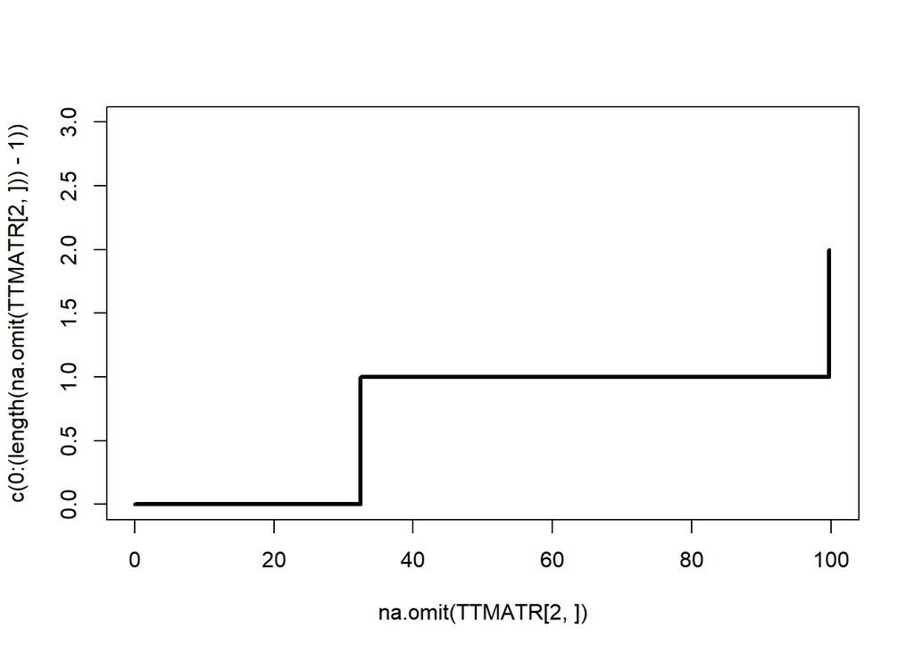

```r
plot(na.omit(TTMATR[2, ]), c(0:(length(na.omit(TTMATR[2, ])) -
    1)), xlim = c(0, tau), ylim = c(0, length(TT)), type = "s",
    lwd = 3)
```